# Chapter 3 - Single - Variable Statistics

Any numerical quantity computed from data is known as a **statistic**.

We will be looking at different statistics to describe data sets.

```python
import numpy as np
import matplotlib.pyplot as plt
import pandas as pd

data = pd.Series([1,2,1,4,4,3,4,4,5,7,8,13,5,6,6,6,6,6,7,8,])
data.sort_values()
```

```
0      1
2      1
1      2
5      3
3      4
4      4
6      4
7      4
8      5
12     5
13     6
14     6
15     6
16     6
17     6
9      7
18     7
10     8
19     8
11    13
dtype: int64
```

# Sample Mean

Given a set of observation $x_1, x_2, x_3\dots, x_n$, we define the **sample mean**, $\overline{x}$ as $$\overline{x} = \frac{x_1+x_2+x_3+\cdots+x_n}{n} = \frac{1}{n}\sum_{i=1}^n x_i.$$ Alternatively, this is often called the average.

```python
data.mean()
```

```
np.float64(5.3)
```

# Deviations

The differences between the observed values and the sample means are the **deviations**.

```python
x_bar = data.mean()
data - x_bar
```

```
0    -4.3
1    -3.3
2    -4.3
3    -1.3
4    -1.3
5    -2.3
6    -1.3
7    -1.3
8    -0.3
9     1.7
10    2.7
11    7.7
12   -0.3
13    0.7
14    0.7
15    0.7
16    0.7
17    0.7
18    1.7
19    2.7
dtype: float64
```

# Sample Median

The **sample median** is the "middle value" of the data. That is, suppose we order the data from smallest to largest, if there are $2n+1$ observations (odd), then the median is the $(n+1)$st observation, while if the are $2n$ observations (even), then the median is the average of the $n$th and $(n+1)$st observations.

```python
data.median()
```

```
np.float64(5.5)
```

# Percentiles

The sample $100p$, $0\leq p\leq 1$, percentile is that data value having the property that at least $100p$ percent of the data are less than or equal to it and at least $100(1 − p)$ percent of the data values are greater than or equal to it. If two data values satisfy this condition, then the sample $100p$ percentile is the arithmetic average of these values.

```python
data.quantile(0.7, interpolation='midpoint')
```

```
np.float64(6.0)
```

```python
data.quantile(0.95, interpolation='midpoint')
```

```
np.float64(10.5)
```

# Sample Mode

The **sample mode** is the observation that occurs most frequently in the data set.

```python
data_pandas = pd.Series(data)
data.value_counts()
```

```
6     5
4     4
1     2
7     2
5     2
8     2
2     1
3     1
13    1
Name: count, dtype: int64
```

# Sample Variance and Sample Standard Deviation

Given a set of observation $x_1, x_2, x_3\dots, x_n$, we define the **sample variance**, $s^2$ as $$s^2 =\frac{1}{n-1}\sum_{i=1}^n (x_i-\overline{x})^2$$ and the **sample standard deviation** as $s$.

A useful algebraic identity for the sample variance is that $$s^2 = \frac{1}{n-1}\left(\sum_{i=1}^nx_i^2-n\overline{x}^2\right).$$

(Note that in the formulas above, $\overline{x}$ is the sample mean.)

```python
data.var()
```

```
np.float64(7.48421052631579)
```

```python
data.std()
```

```
np.float64(2.735728518386974)
```

```python
data.std()**2
```

```
np.float64(7.484210526315789)
```

# Interquartile Range and Box Plots

A **box plot** is a plot drawn either as a horizontal or vertical line from the smallest to largest values observed in a data set. A box is placed on the line that starts at the $1$st quartile (the $25$th percentile), $Q_1$, to the $3$rd quartile ($75$th percentile), $Q_3$, with a line in between indicating the $2$nd quartile (the $50$th percentile, or median), $Q_2$.

The **interquartile range**, $IQR$, is given by $IQR = Q_3-Q_1$. This is often used to illustrate extreme values (often referred to as **outliers**). For example, some box plots consider anything greater than $Q_3 + 1.5 IQR$ and smaller than $Q_1 - 1.5 IQR$ as an outlier.

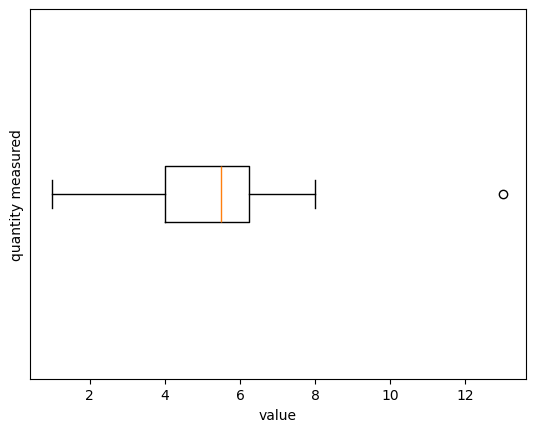

```python
plt.boxplot(data, vert=False)
plt.ylabel('quantity measured')
plt.xlabel('value')
plt.yticks([])
plt.show()
```

# Skewness

Skewness is a descriptor for non-symmetric data. We give several examples under the assumption that the data set is **unimodal**, i.e. - it has only one peak.

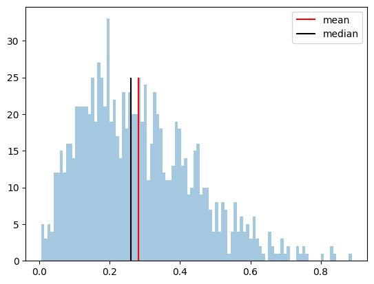

```python
# Right-skewed - mean is larger than the median

right_skew_data = pd.Series(np.random.beta(2,5,size=1000))
plt.hist(right_skew_data, bins=100, alpha=0.4)
plt.vlines(right_skew_data.mean(),0,25,color='red',label='mean')
plt.vlines(right_skew_data.quantile(0.50),0,25,color='black',label='median')
plt.legend()
plt.show()
```

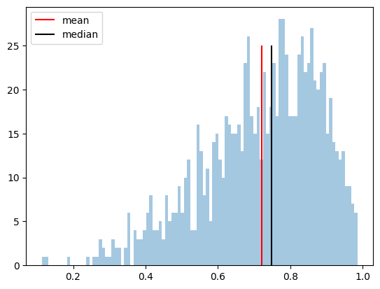

```python
# Left-skewed - mean is smaller than the median

left_skew_data = pd.Series(1 - np.random.beta(2,5,size=1000))
plt.hist(left_skew_data, bins=100, alpha=0.4)
plt.vlines(left_skew_data.mean(),0,25,color='red',label='mean')
plt.vlines(left_skew_data.quantile(0.50),0,25,color='black',label='median')
plt.legend()
plt.show()
```

# Summary Statistics using Pandas

```python
data.describe()
```

```
count    20.000000
mean      5.300000
std       2.735729
min       1.000000
25%       4.000000
50%       5.500000
75%       6.250000
max      13.000000
dtype: float64
```

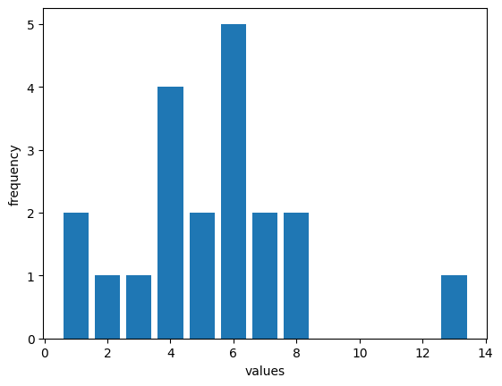

```python
sorted_data = data.value_counts().sort_index()
plt.bar(sorted_data.index, sorted_data)
plt.xlabel('values')
plt.ylabel('frequency')
plt.show()
```